# Week_7_Assignment

Sekhar Mekala

Wednesday, March 18, 2015

# Initial analysis

We are given the following information:

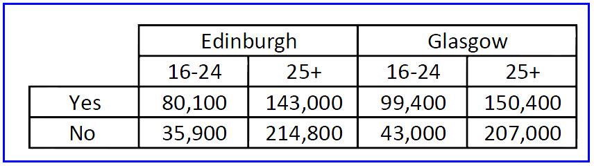

**Table 1: Given data in the question**

This table contains the results of a poll conducted at two different cities Edinburgh and Glasgow, under two different age groups.

# Questions and answers

**Question 1** Write down 3 questions that you might want to answer based on this data.

**Answer** I would like to know the following information from the given data:

- Get the percentage of votes (yes/no) by city, irrespective of the age groups. We would like to see how each city’s population has voted.
- Get the percentage of yes/no, by age group, irrespective of the city
- Get the precentage of yes/no by age group and by city

**NOTE** A “Yes” vote means, the population prefers Cullen skink and “No” vote means the population prefers Partan bree.

**Question 2** Create an R data frame with 2 observations to store this data in its current “messy” state. Use whatever method you want to re-create and/or load the data.

**Answer**

```r
Edinburgh.Yes <- c(80100,143000)
Edinburgh.No <- c(35900,214800)
Glasgow.Yes <- c(99400,150400)
Glasgow.No <- c(43000,207000)

polls <- data.frame(Edinburgh.Yes = Edinburgh.Yes,Edinburgh.No, Glasgow.Yes, Glasgow.No)
rownames(polls) <- c('16-24','25+')

polls
```

```
##       Edinburgh.Yes Edinburgh.No Glasgow.Yes Glasgow.No
## 16-24         80100        35900       99400      43000
## 25+          143000       214800      150400     207000
```

**Figure 1: Data Frame**

**Question 3:** Use the functionality in the tidyr package to convert the data frame to be “tidy data.”

**Answer** The data frame shown in **Figure 1** is certainly a messy data set, due to the following reasons: 1. The columns Einburgh.Yes, Edinburgh.No, Glasgow.Yes and Glasgow.No are not variables. 2. The row names “16-24” and “25+” are also not variables.

Let us first fix the usage of constants as row names (2nd issue listed above). To the “polls” data set, let us add a new variable called “Age_Group” with two observations: 16-24 and 25+, and delete the row names.

```r
library(tidyr)
library(dplyr)
polls <- mutate(polls,Age_Group=rownames(polls))
rownames(polls) <- NULL

polls
```

```
##   Edinburgh.Yes Edinburgh.No Glasgow.Yes Glasgow.No Age_Group
## 1         80100        35900       99400      43000     16-24
## 2        143000       214800      150400     207000       25+
```

```r
polls <- gather(polls,City,Votes,-Age_Group)
polls
```

```
##   Age_Group          City  Votes
## 1     16-24 Edinburgh.Yes  80100
## 2       25+ Edinburgh.Yes 143000
## 3     16-24  Edinburgh.No  35900
## 4       25+  Edinburgh.No 214800
## 5     16-24   Glasgow.Yes  99400
## 6       25+   Glasgow.Yes 150400
## 7     16-24    Glasgow.No  43000
## 8       25+    Glasgow.No 207000
```

**Figure 2: Data Frame, after converting the row names as observations**

The above display of polls data frame is still not tidy, since the City name is concatenated with the opinion data (Yes/No). We have to separate this data (under the City column into 2 columns: City and the Opinion). The code is shown below:

```r
  polls <- separate(polls,City,into=c("City","Opinion"), sep = "\\.")
  polls
```

```
##   Age_Group      City Opinion  Votes
## 1     16-24 Edinburgh     Yes  80100
## 2       25+ Edinburgh     Yes 143000
## 3     16-24 Edinburgh      No  35900
## 4       25+ Edinburgh      No 214800
## 5     16-24   Glasgow     Yes  99400
## 6       25+   Glasgow     Yes 150400
## 7     16-24   Glasgow      No  43000
## 8       25+   Glasgow      No 207000
```

**Question 4:** Use the functionality in the dplyr package to answer the questions that you asked in step 1.

**Answer** * Get the percentage of votes (yes/no) by city, irrespective of the age groups. We would like to see how each city’s population has voted.

```r
s_Edinburgh <- sum(polls[polls$City=="Edinburgh",]$Votes)
s_Glasgow <- sum(polls[polls$City=="Glasgow",]$Votes)

polls_by_city <- summarise(group_by(polls,City, Opinion),Votes=(sum(Votes)))

polls_by_city$Votes[polls_by_city$City=="Edinburgh"] <- (polls_by_city$Votes[polls_by_city$City=="Edinburgh"] / s_Edinburgh)*100
polls_by_city$Votes[polls_by_city$City=="Glasgow"] <- (polls_by_city$Votes[polls_by_city$City=="Glasgow"] / s_Glasgow)*100

polls_by_city
```

```
## Source: local data frame [4 x 3]
## Groups: City
##
##        City Opinion    Votes
## 1 Edinburgh      No 52.91262
## 2 Edinburgh     Yes 47.08738
## 3   Glasgow      No 50.02001
## 4   Glasgow     Yes 49.97999
```

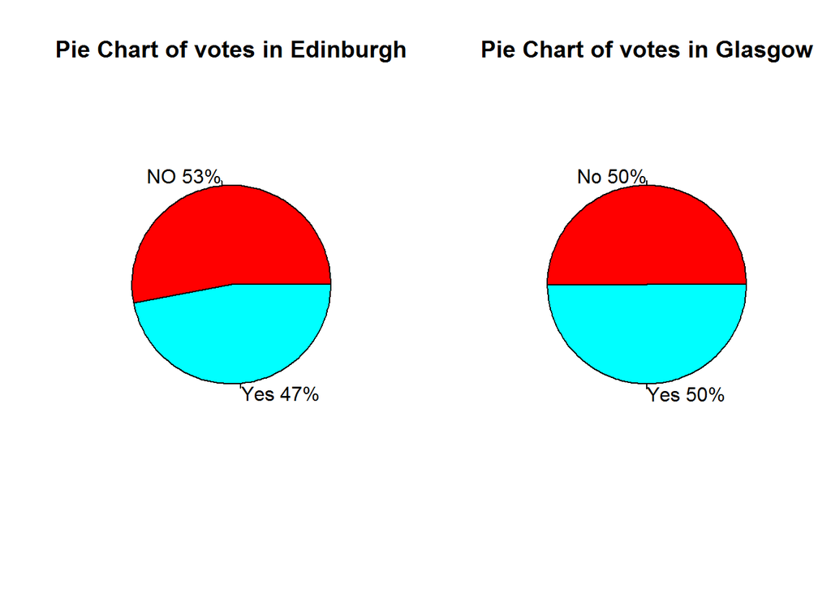

```r
par(mfrow=c(1,2))

slices <- c(polls_by_city$Votes[polls_by_city$City=="Edinburgh"])

lbls <- c("NO", "Yes")

lbls <- paste(lbls, round(slices))
 lbls <- paste(lbls,"%",sep="")
 pie(slices,labels = lbls, col=rainbow(length(lbls)),
    main="Pie Chart of votes in Edinburgh")


slices <- c(polls_by_city$Votes[polls_by_city$City=="Glasgow"])



lbls <- c("No","Yes")


lbls <- paste(lbls, round(slices))
 lbls <- paste(lbls,"%",sep="")
 pie(slices,labels = lbls, col=rainbow(length(lbls)),
    main="Pie Chart of votes in Glasgow")
```

**Conclusion-1:** Approximately 53% of Edinburgh’s population has voted “No”, while 47% of Edinburgh’s population has voted “Yes”

Approximately 50% of Glasgow’s population has voted “Yes” and 50% has voted “No”

In Edinburgh, majority of the people (53%) prefer Partan Bree (since “no” is the majority population’s choice.) In Glasgow, the votes are divided almost the same (50%) between Partan Bree and Cullen Skink

- Get the percentage of yes/no, by age group, irrespective of the city.

```r
s_16_24_age <- sum(polls[polls$Age_Group=="16-24",]$Votes)
s_25_age <- sum(polls[polls$Age_Group=="25+",]$Votes)

polls_by_age_group <- summarise(group_by(polls,Age_Group, Opinion),Votes=(sum(Votes)))

polls_by_age_group$Votes[polls_by_age_group$Age_Group == "16-24"] <- (polls_by_age_group$Votes[polls_by_age_group$Age_Group == "16-24"] / s_16_24_age)*100
polls_by_age_group$Votes[polls_by_age_group$Age_Group == "25+"] <- (polls_by_age_group$Votes[polls_by_age_group$Age_Group == "25+"] / s_25_age)*100

polls_by_age_group
```

```
## Source: local data frame [4 x 3]
## Groups: Age_Group
##
##   Age_Group Opinion    Votes
## 1     16-24      No 30.53406
## 2     16-24     Yes 69.46594
## 3       25+      No 58.97651
## 4       25+     Yes 41.02349
```

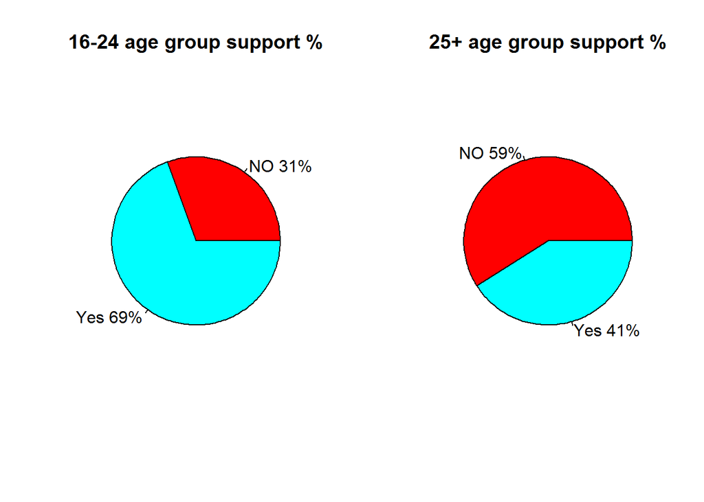

```r
par(mfrow=c(1,2))

slices <- c(polls_by_age_group$Votes[polls_by_age_group$Age_Group == "16-24"])
lbls <- c("NO", "Yes")

lbls <- paste(lbls, round(slices)) # add percents to labels
 lbls <- paste(lbls,"%",sep="") # ad % to labels
 pie(slices,labels = lbls, col=rainbow(length(lbls)),
    main="16-24 age group support %")


slices <- c(polls_by_age_group$Votes[polls_by_age_group$Age_Group == "25+"])
lbls <- c("NO", "Yes")

lbls <- paste(lbls, round(slices)) # add percents to labels
 lbls <- paste(lbls,"%",sep="") # ad % to labels
 pie(slices,labels = lbls, col=rainbow(length(lbls)),
    main="25+ age group support %")
```

**Conclusion-2:** Approximately 41% of 25+ age group has voted for Yes, and 69.5% of 16-24 age group has voted for Yes. Hence the majority of the 25+ age group population has voted “No”, while the majority of 16-24 age group population has voted for yes.

Hence 59% of 25+ age group prefer Partan Bree, while in 16-24 age group the majority (69.5%) prefer Cullen Skink. The support/voting pattern changes depending on the age group.

- Get the precentage of yes/no by age group and by city.

```r
poll_percents <- polls
poll_percents$Votes[poll_percents$City == "Edinburgh"] <- (poll_percents$Votes[poll_percents$City == "Edinburgh"] / s_Edinburgh) * 100
poll_percents$Votes[poll_percents$City == "Glasgow"] <- (poll_percents$Votes[poll_percents$City == "Glasgow"] / s_Glasgow) * 100
poll_percents
```

```
##   Age_Group      City Opinion     Votes
## 1     16-24 Edinburgh     Yes 16.905867
## 2       25+ Edinburgh     Yes 30.181511
## 3     16-24 Edinburgh      No  7.577037
## 4       25+ Edinburgh      No 45.335585
## 5     16-24   Glasgow     Yes 19.887955
## 6       25+   Glasgow     Yes 30.092037
## 7     16-24   Glasgow      No  8.603441
## 8       25+   Glasgow      No 41.416567
```

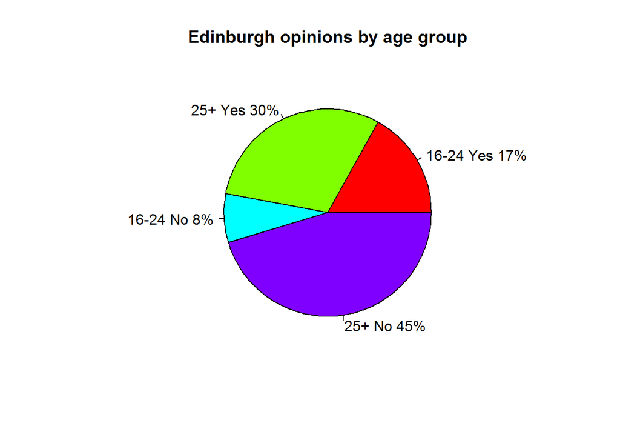

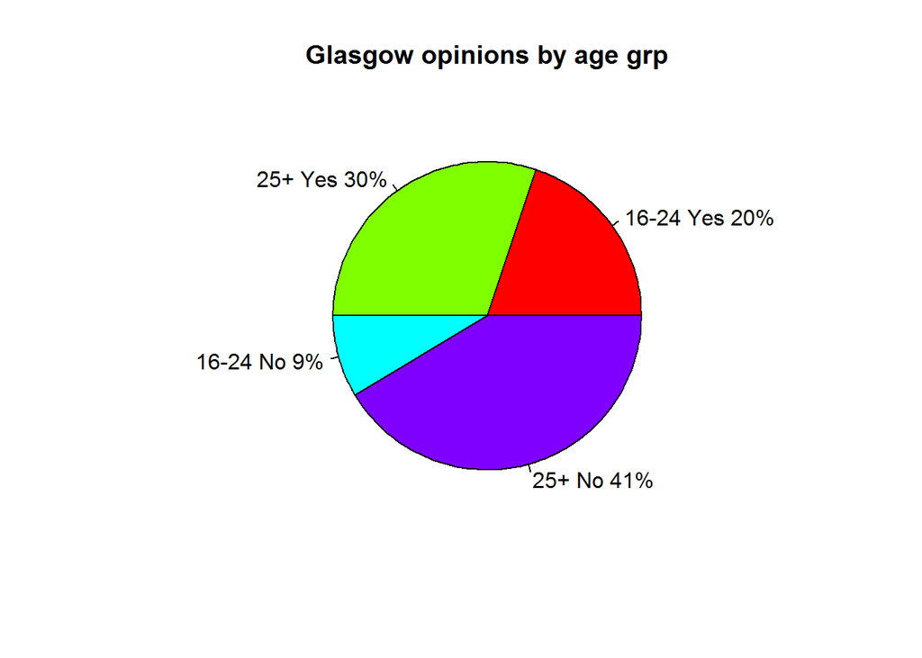

**NOTE** Percentages might not add up to 100, due to rounding of decimals.

**Question 5**: Having gone through the process, would you ask different questions and/or change the way that you structured your data frame?

**Answer** I would like to convert the poll_percents data frame to the following display, using spread() function of tidyr. Such display will help us to compare the votes percentages side by side.

```r
library(tidyr)
poll_percents$City_Opinion <- paste(poll_percents$City,".",poll_percents$Opinion,sep="")
poll_percents$City <- NULL
poll_percents$Opinion <- NULL
spread(poll_percents,City_Opinion, Votes)
```

```
##   Age_Group Edinburgh.No Edinburgh.Yes Glasgow.No Glasgow.Yes
## 1     16-24     7.577037      16.90587   8.603441    19.88796
## 2       25+    45.335585      30.18151  41.416567    30.09204
```